# Webscraping with Selenium Guide

Here is my guide to webscrape the Discourse Forums with Selenium. I believe the information below is enough to get you started.

#### Basic Setup:

Set up for Selenium: https://youtu.be/FFDDN1C1MEQ

Driver installation for MacOS: https://medium.com/technowriter/install-selenium-on-mac-os-x-94c7a216aeb0

#### Get familiar with the general syntax here:

Remeber the structure of our webpage is different from the one on this post.

Tip: right click element you want to extract and click "inspect" to find where it is in the HTML structure

https://towardsdatascience.com/web-scraping-using-selenium-python-8a60f4cf40ab

#### Get specific here:

Learn how xpath works: https://www.guru99.com/xpath-selenium.html

Tip: you can right click "Copy XPath" or "Copy full XPath"

Add the extra for loop for reloading the page:

How to solve infinite scroll with Selenium: http://raghavendra990.github.io/2015/08/22/scrapping-using-selenium.html

#### DataFrame specifics

Aim for a column with topic title and a column with the category it is from

If you want to do more attributes, discuss on the Slack so the other groups will be notified to scrape the data too (other attributes that might be useful include: replies, activity, last user comment, user who posted, text of post). One thing to note is that if it's irrelevant it might lead to overfitting but we can always just not use it.

We will combine the data as following:

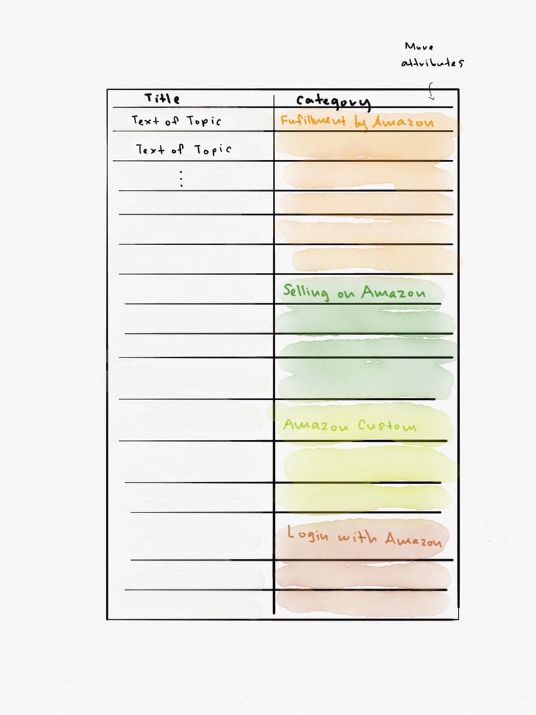

```python
from IPython.display import Image
from IPython.core.display import HTML
Image(filename = "../Images/c.png", width=700, height=800)
```

#### If extra support is needed checkout the template I have provided:

Look at this after you have tried things out to get a better understanding. Or look at it to understand and generate ideas then try coding without looking at it. Note: you guys do not have follow this format. The important thing is to get the data, keeping in mind to build it in a way that adding columns later isn't too hard.